# EP08-respuesta-equipo-4.Rmd

2026-07-14

# Pregunta 1:

LECTURA DATASET

```r
# Cargar datos
casen <- read.csv("EP08 Datos CASEN 2017.csv", stringsAsFactors = FALSE)

# Limpieza básica de formatos
casen <- casen %>%
  mutate(
    region = as.character(region),
    sexo = as.character(sexo),
    edad = as.numeric(edad),
    ecivil = as.character(ecivil),
    educ = as.character(educ),
    ytotcorh = as.numeric(ytotcorh)
  )
```

*Pregunta de investigación:* Considerando una muestra aleatoria de hogares de la Región de Tarapacá, ¿existe una diferencia significativa en la proporción de mujeres adultas (mayores de 18 años) que han alcanzado educación superior entre aquellas que están casadas (o conviviendo) y aquellas que no tienen pareja?

*Argumento en simple del experimento:* Esta pregunta compara la frecuencia de una característica categórica (haber alcanzado educación superior) entre dos grupos independientes de mujeres adultas (con pareja y sin pareja), cumpliendo con lo solicitado para esta actividad.

#### Hipótesis a contrastar

##### $H_0$: La proporción de mujeres con educación superior es igual en ambos grupos (la diferencia de proporciones es 0).

##### $H_A$: La proporción de mujeres con educación superior es diferente entre ambos grupos (la diferencia de proporciones es distinta de 0).

#### Preparación de la Muestra

Filtramos a las mujeres adultas de Tarapacá y recodificamos el estado civil y el nivel educacional. Luego, extraemos una muestra aleatoria de hogares (130 viviendas).

```r
datos_p1_poblacion <- casen %>%
  filter(grepl("Tarapacá|Tarapaca", region, ignore.case = TRUE)) %>%
  filter(sexo == "Mujer" & edad >= 18) %>%
  filter(!is.na(ecivil) & !is.na(educ)) %>%
  mutate(
    estado_civil_agrup = case_when(
      grepl("Casado|Conviviente", ecivil, ignore.case = TRUE) ~ "Con_Pareja",
      grepl("Soltero|Separado|Divorciado|Viudo|Anulado", ecivil, ignore.case = TRUE) ~ "Sin_Pareja",
      TRUE ~ "Otro"
    ),
    # Creamos una variable binaria para contar los éxitos más fácil
    educ_superior = ifelse(grepl("Técnica|Profesional|Postgrado", educ, ignore.case = TRUE), 1, 0)
  ) %>%
  filter(estado_civil_agrup != "Otro")

# Muestreo aleatorio de HOGARES (100 < n < 150)
set.seed(42)
ids_muestra_p1 <- sample(unique(datos_p1_poblacion$id.vivienda), 130)

# Filtramos a las personas de los hogares sorteados y elegimos SOLO UNA al azar por hogar
datos_p1 <- datos_p1_poblacion %>%
  filter(id.vivienda %in% ids_muestra_p1) %>%
  group_by(id.vivienda) %>%
  slice_sample(n = 1) %>%
  ungroup()


# Le ponemos un factor con etiquetas para que los gráficos salgan bonitos
datos_p1$educ_superior_factor <- factor(datos_p1$educ_superior,
                                         labels = c("Sin Ed. Superior", "Con Ed. Superior"))

cat("Número de hogares sorteados:", length(ids_muestra_p1), "\n")
```

```
## Número de hogares sorteados: 130
```

```r
cat("Número de mujeres adultas analizadas:", nrow(datos_p1), "\n")
```

```
## Número de mujeres adultas analizadas: 130
```

#### Análisis descriptivo

```r
tabla_frecuencias <- table(datos_p1$estado_civil_agrup, datos_p1$educ_superior_factor)
cat("--- Frecuencias absolutas ---\n")
```

```
## --- Frecuencias absolutas ---
```

```r
print(tabla_frecuencias)
```

```
##
##              Sin Ed. Superior Con Ed. Superior
##   Con_Pareja               42               10
##   Sin_Pareja               62               16
```

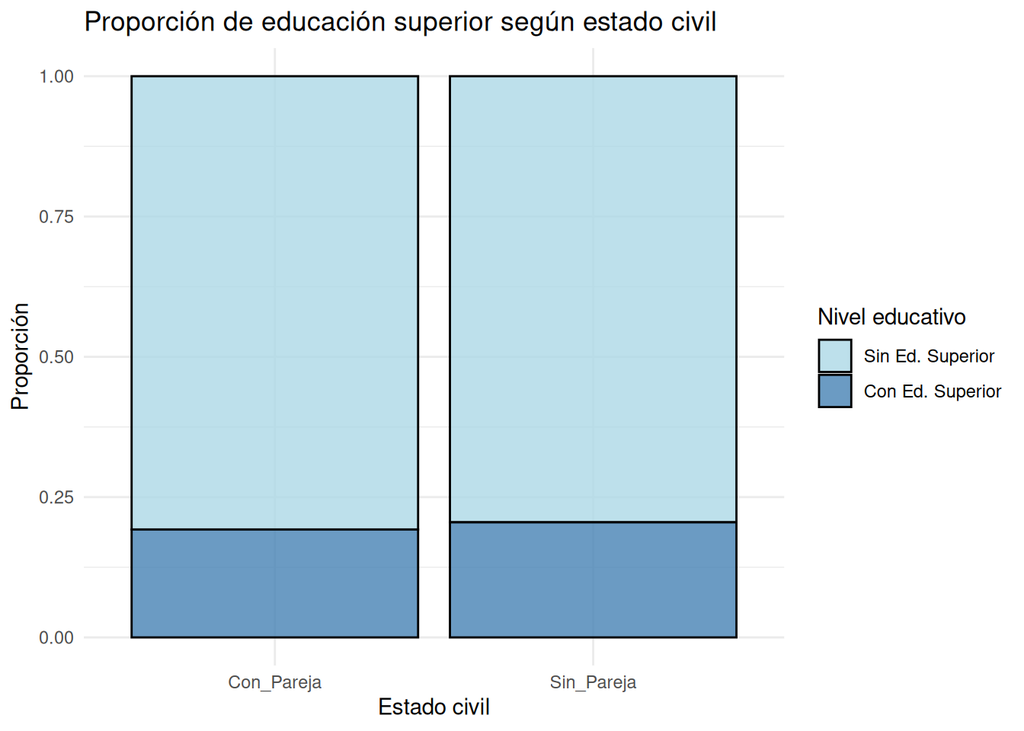

```r
ggplot(datos_p1, aes(x = estado_civil_agrup, fill = educ_superior_factor)) +
  geom_bar(position = "fill", color = "black", alpha = 0.8) +
  scale_fill_manual(values = c("lightblue", "steelblue")) +
  labs(title = "Proporción de educación superior según estado civil",
       x = "Estado civil", y = "Proporción", fill = "Nivel educativo") +
  theme_minimal()
```

```r
# Calculamos las proporciones a mano para ver la diferencia
prop_obs <- tapply(datos_p1$educ_superior, datos_p1$estado_civil_agrup, mean)
dif_obs <- prop_obs["Con_Pareja"] - prop_obs["Sin_Pareja"]
cat("\nProporción Con Pareja:", prop_obs["Con_Pareja"], "\n")
```

```
##
## Proporción Con Pareja: 0.1923077
```

```r
cat("Proporción Sin Pareja:", prop_obs["Sin_Pareja"], "\n")
```

```
## Proporción Sin Pareja: 0.2051282
```

```r
cat("Diferencia observada:", dif_obs, "\n")
```

```
## Diferencia observada: -0.01282051
```

Verificación de condiciones para prueba paramétrica Antes de lanzar el remuestreo, queremos ver si podíamos usar una prueba clásica (como chi-cuadrado). Para eso, la condición de Cochran nos pide que las frecuencias esperadas en la tablita sean de al menos 5.

```r
esperados <- chisq.test(tabla_frecuencias, correct = FALSE)$expected
cat("--- Frecuencias esperadas bajo H0 ---\n")
```

```
## --- Frecuencias esperadas bajo H0 ---
```

```r
print(esperados)
```

```
##
##              Sin Ed. Superior Con Ed. Superior
##   Con_Pareja             41.6             10.4
##   Sin_Pareja             62.4             15.6
```

```r
cat("\n¿Todas las frecuencias esperadas son >= 5?:", all(esperados >= 5), "\n")
```

```
##
## ¿Todas las frecuencias esperadas son >= 5?: TRUE
```

#### Prueba de permutaciones Monte Carlo (para sacar el p-valor)

Esta prueba simula qué pasaría si no hubiera ninguna relación entre el estado civil y la educación. Mezclamos las etiquetas casi diez mil veces para armar un mundo donde el azar manda.

```r
B <- 9999
dist_permutaciones <- numeric(B)
n_con_pareja <- sum(datos_p1$estado_civil_agrup == "Con_Pareja")
total_datos <- nrow(datos_p1)

set.seed(123)  # Fijamos semilla para que el profesor pueda replicar esto exacto
for (i in 1:B) {
  educ_mezclada <- sample(datos_p1$educ_superior)
  p_falsa_con <- mean(educ_mezclada[1:n_con_pareja])
  p_falsa_sin <- mean(educ_mezclada[(n_con_pareja + 1):total_datos])
  dist_permutaciones[i] <- p_falsa_con - p_falsa_sin
}

# Calculamos el p-valor de dos colas
p_valor_p1 <- (sum(abs(dist_permutaciones) >= abs(dif_obs)) + 1) / (B + 1)
cat("Diferencia observada en la muestra real:", dif_obs, "\n")
```

```
## Diferencia observada en la muestra real: -0.01282051
```

```r
cat("P-valor (permutaciones):", p_valor_p1, "\n")
```

```
## P-valor (permutaciones): 1
```

#### Intervalo de confianza para la diferencia de proporciones (Bootstrap)

La prueba de arriba mezcla etiquetas, así que está centrada en 0. Pero si queremos saber dónde cae el intervalo de confianza real de nuestra diferencia, tenemos que usar bootstrap: sacar remuestras con reemplazo pero respetando quién es quién.

```r
B_boot <- 9999
dif_boot <- numeric(B_boot)

set.seed(456)  # Otra semilla para no mezclar procesos
for (i in 1:B_boot) {
  # Sacamos una muestra con reemplazo del mismo tamaño
  muestra_boot <- datos_p1[sample(nrow(datos_p1), replace = TRUE), ]
  p_boot <- tapply(muestra_boot$educ_superior, muestra_boot$estado_civil_agrup, mean)
  dif_boot[i] <- p_boot["Con_Pareja"] - p_boot["Sin_Pareja"]
}

# Sacamos los cuantiles para armar el intervalo del 95%
ic_boot <- quantile(dif_boot, c(0.025, 0.975), na.rm = TRUE)
cat("Diferencia observada:", dif_obs, "\n")
```

```
## Diferencia observada: -0.01282051
```

```r
cat("Intervalo de confianza 95% (bootstrap): [", ic_boot[1], ",", ic_boot[2], "]\n")
```

```
## Intervalo de confianza 95% (bootstrap): [ -0.15 , 0.1306842 ]
```

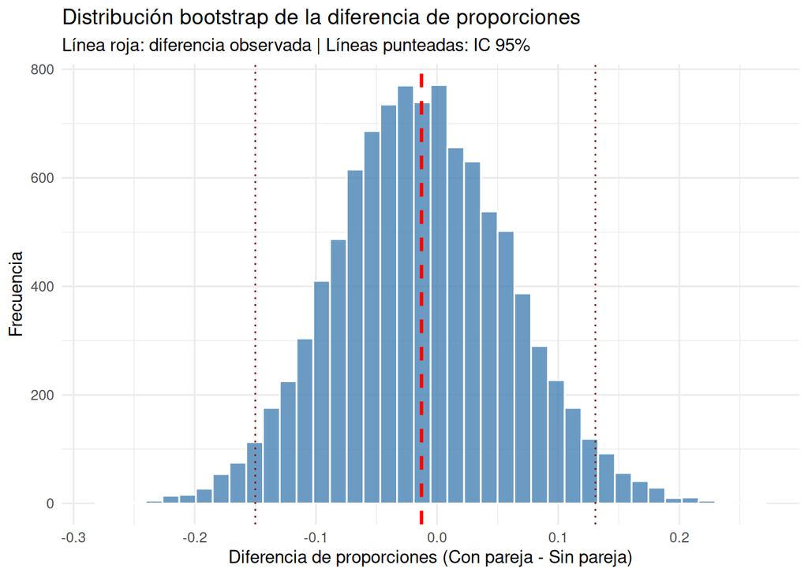

```r
# Visualizamos la distribución de las remuestras
ggplot(data.frame(dif_boot = dif_boot), aes(x = dif_boot)) +
  geom_histogram(bins = 40, fill = "steelblue", color = "white", alpha = 0.8) +
  geom_vline(xintercept = dif_obs, color = "red", linetype = "dashed", linewidth = 1) +
  geom_vline(xintercept = ic_boot, color = "darkred", linetype = "dotted") +
  labs(title = "Distribución bootstrap de la diferencia de proporciones",
       subtitle = "Línea roja: diferencia observada | Líneas punteadas: IC 95%",
       x = "Diferencia de proporciones (Con pareja - Sin pareja)", y = "Frecuencia") +
  theme_minimal()
```